# Figures and Tables

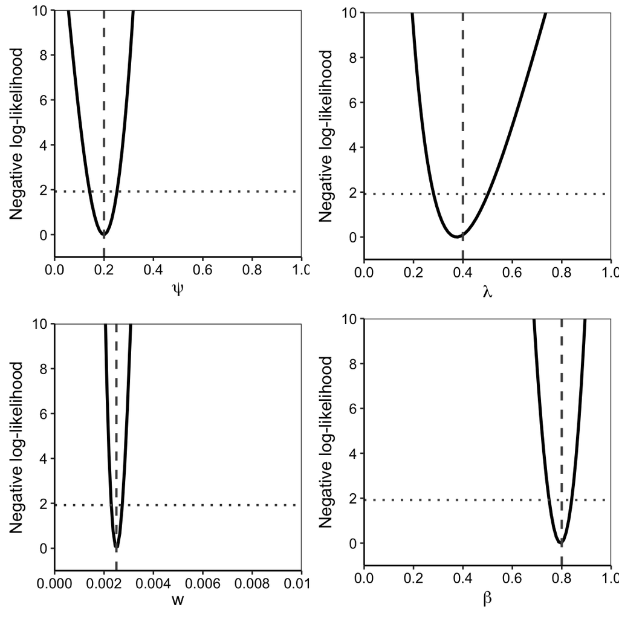

**FIGURE 2: Practical identifiability of mixture model.** A stop-screen trial with 50,000 subjects was simulated with annual screening at ages 50–54 years with follow-up to age 60 years. The outcomes were grouped by screening round to estimate the natural history parameters and screening sensitivity. The parameter values used to generate the synthetic data are indicated by vertical dashed lines, and the point estimates of the four parameters are close to the minima of the negative (profile) log-likelihoods. For each parameter, the intersection of the profile likelihood with the horizontal dotted line defines the 95% profile confidence interval.

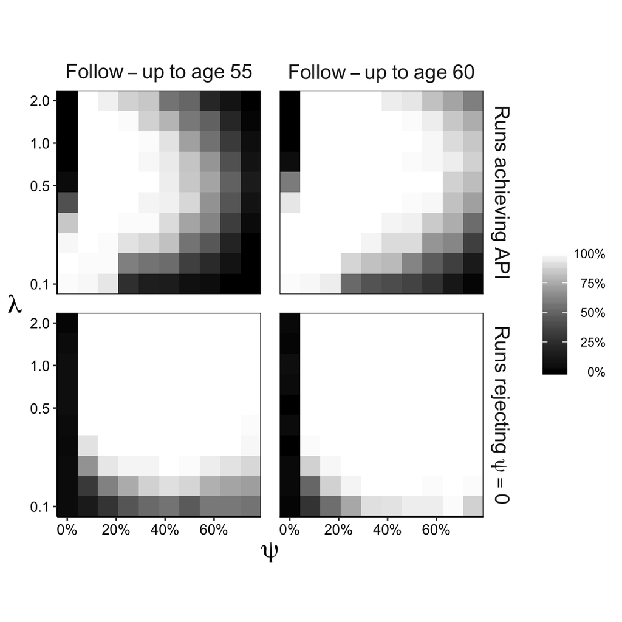

**FIGURE 3: Adequately Precise Identification (API) and type I/II errors.** Model performance over a range of values for the indolent fraction ($\psi$) and the progression rate of progressive cancers ($\lambda$) visualized as (top row) percentages of 100 simulations achieving joint API for all four model parameters and (bottom row) percentages of 100 simulations that reject the null hypothesis $\mathcal{H}_0: \psi=0$. Performance is visualized for 50,000 women screened annually at ages 50–54 years with follow-up to age 55 years (left column) and age 60 years (right column), assuming a constant risk of onset of preclinical cancer of $w=0.0025$ per year, and sensitivity of screening to detect preclinical cancer of $\beta=80\%$.

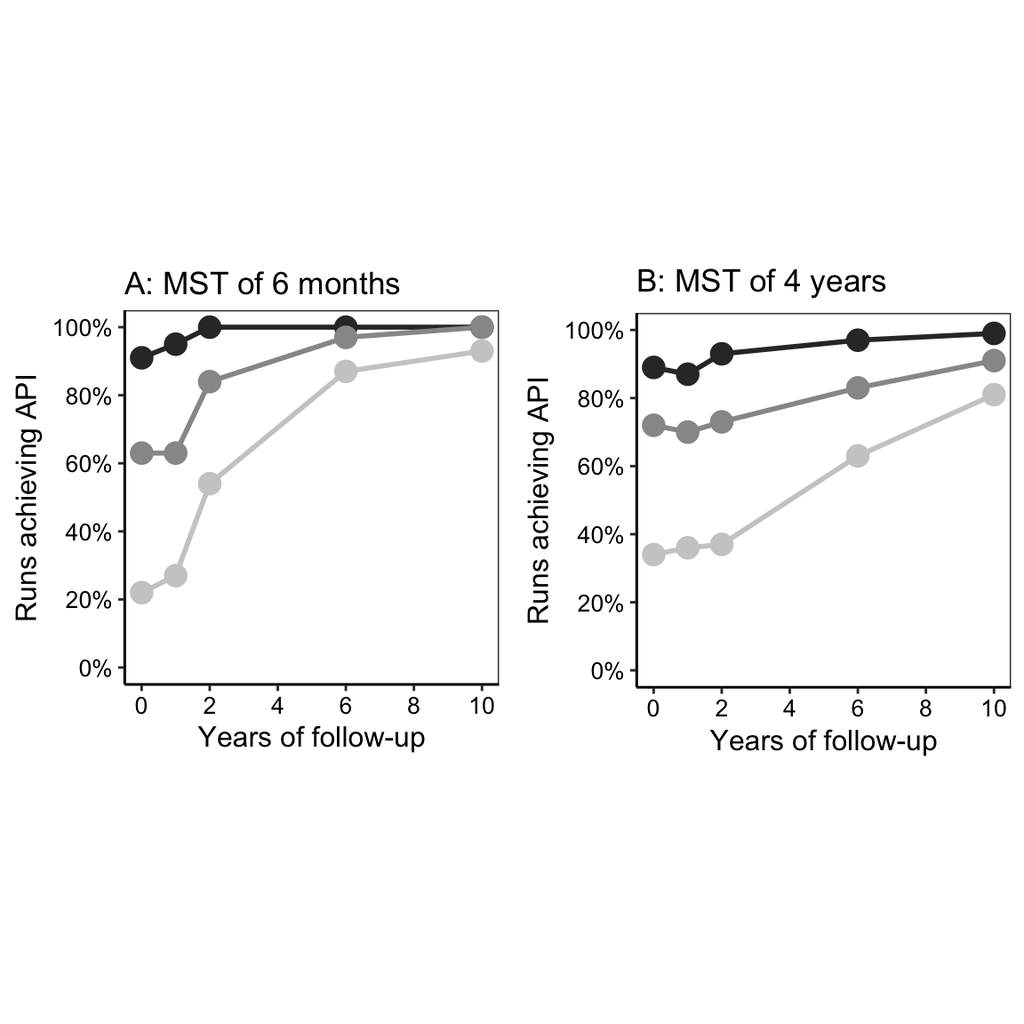

**FIGURE 4: API as a function of follow up.** Percentages of simulations (n=100) achieving joint API for all four model parameters in a stop-screen trial with 50,000 women screened annually at ages 50–54 years, by years of follow-up after the last screen. Mean sojourn time of (A) 6 months and (B) 4 years. Lines connect evaluations under $\psi$ set equal to (dark) 20%, (medium) 40%, and (light) 60%, assuming a constant rate of onset of preclinical cancer of $w=0.0025$ per year, and sensitivity of screening to detect preclinical cancer of $\beta=80\%$.

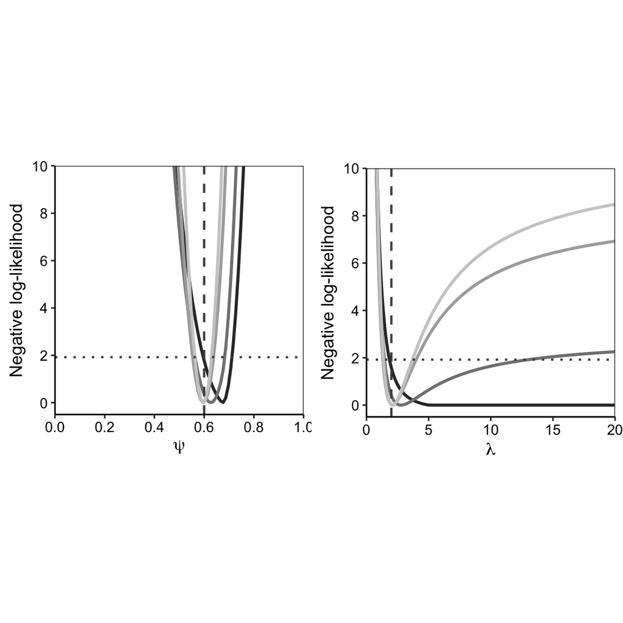

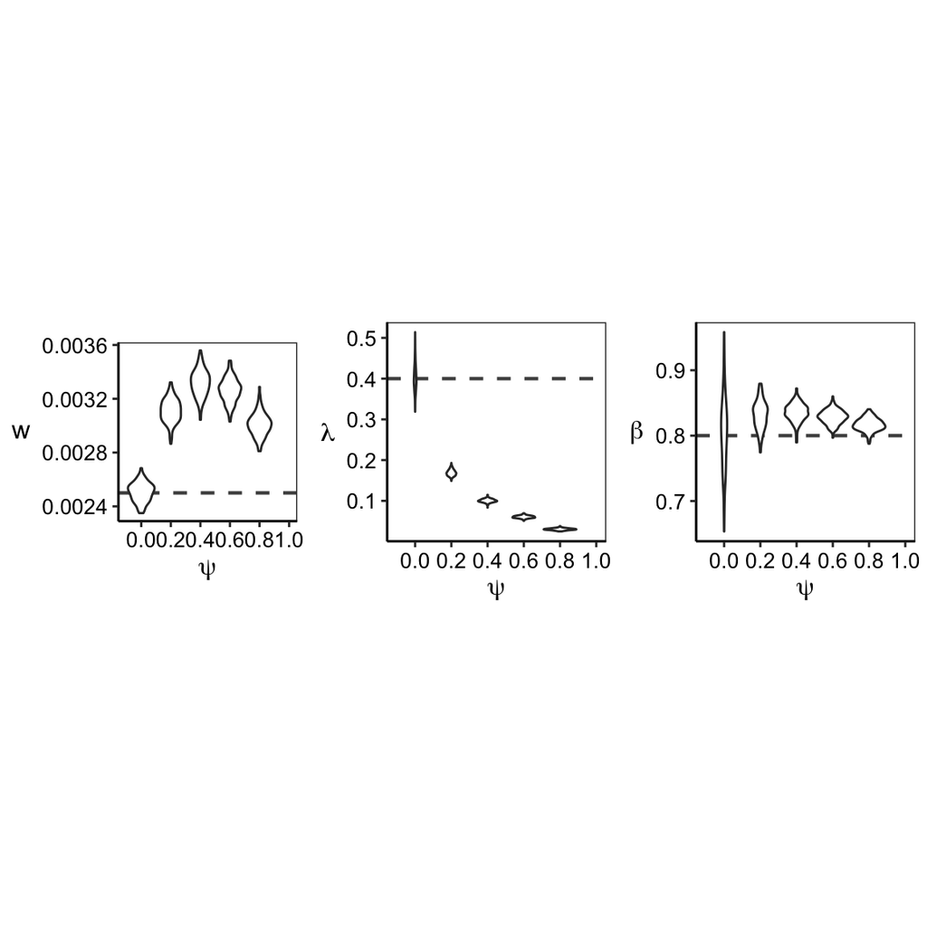

**FIGURE 6: Model misspecification.** Violin plots of maximum likelihood estimates for parameters in a progressive model (i.e., one that assumes $\psi=0$) fit to data generated using a mixture model with selected values of $\psi\ge0$ assuming 50,000 women were screened annually at ages 50–54 with follow-up to age 60 years and the screening test has 80% sensitivity. Dashed horizontal lines indicate true parameter values. Results based on n=200 simulations per $\psi$-value.

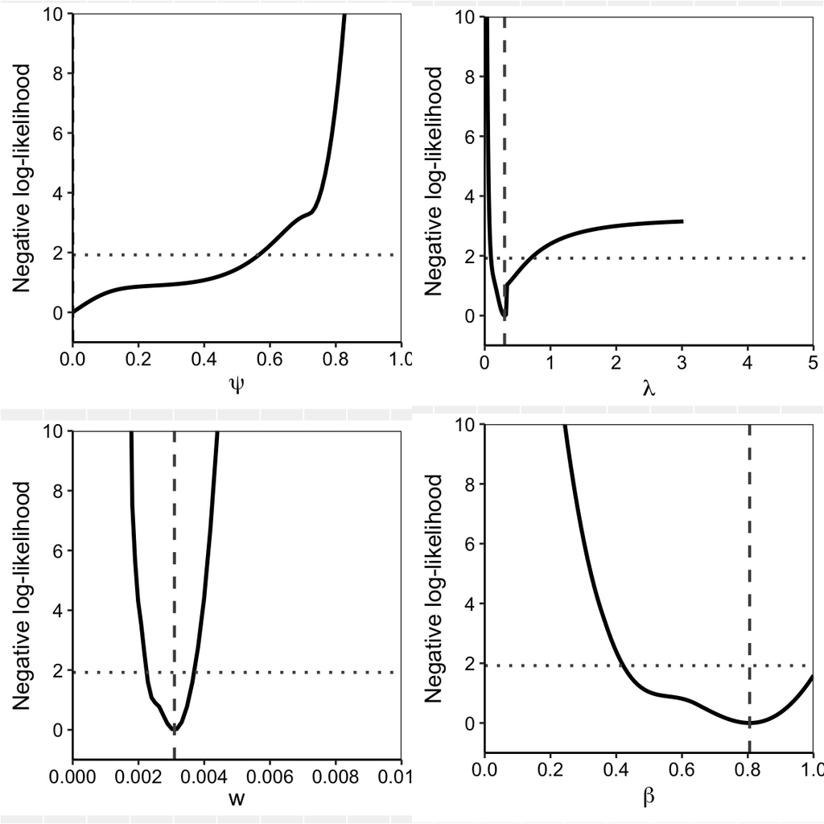

**Figure 7: Profile likelihood for CNBSS-2: mixture model.** Relative negative log-likelihoods (NLL) based on fitting the mixture model to CNBSS-2 data (see Table S1). Vertical dashed lines correspond to maximum likelihood estimates. Intersection of relaitve NLL with horizontal dotted lines indicate the profile-based 95% confidence intervals.

## SUPPLEMENTARY FIGURES AND TABLES

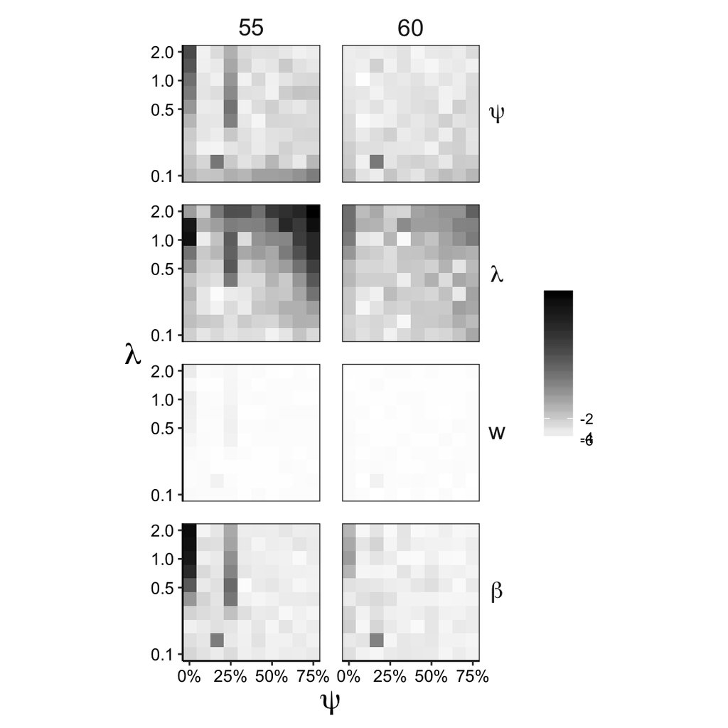

**FIGURE S1: Sensitivity of bias to follow up.** Absolute bias for all four model parameters assuming 50,000 women were screened annually at ages 50–54 years with follow-up to age 55 and 60 years, respectively. Screening test sensitivity was set to $\beta=80\%$.

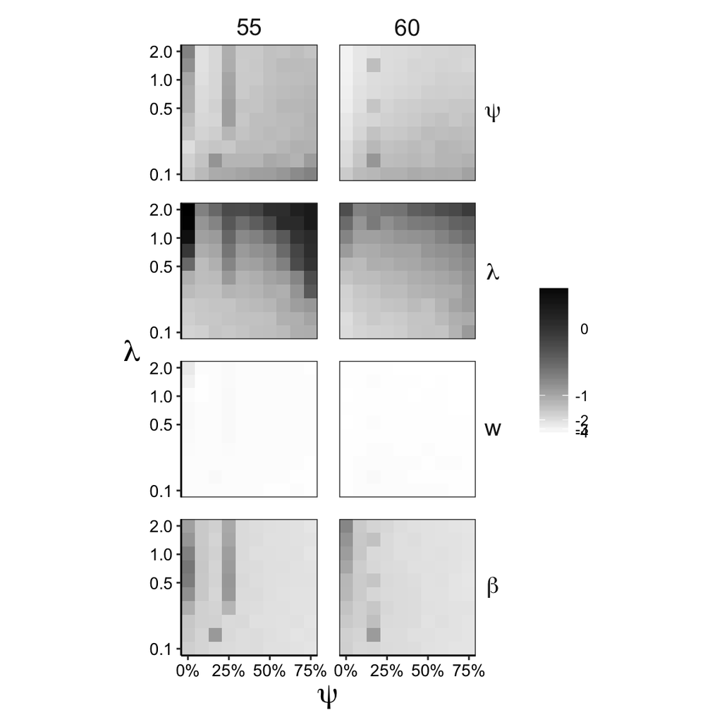

**FIGURE S2: Sensitivity of the standard error to follow up.** Standard errors for all four model parameters assuming 50,000 women were screened annually at ages 50–54 years with follow-up to age 55 and age 60 yearsk respectively. Screening test sensitivity was set to $\beta=80\%$.

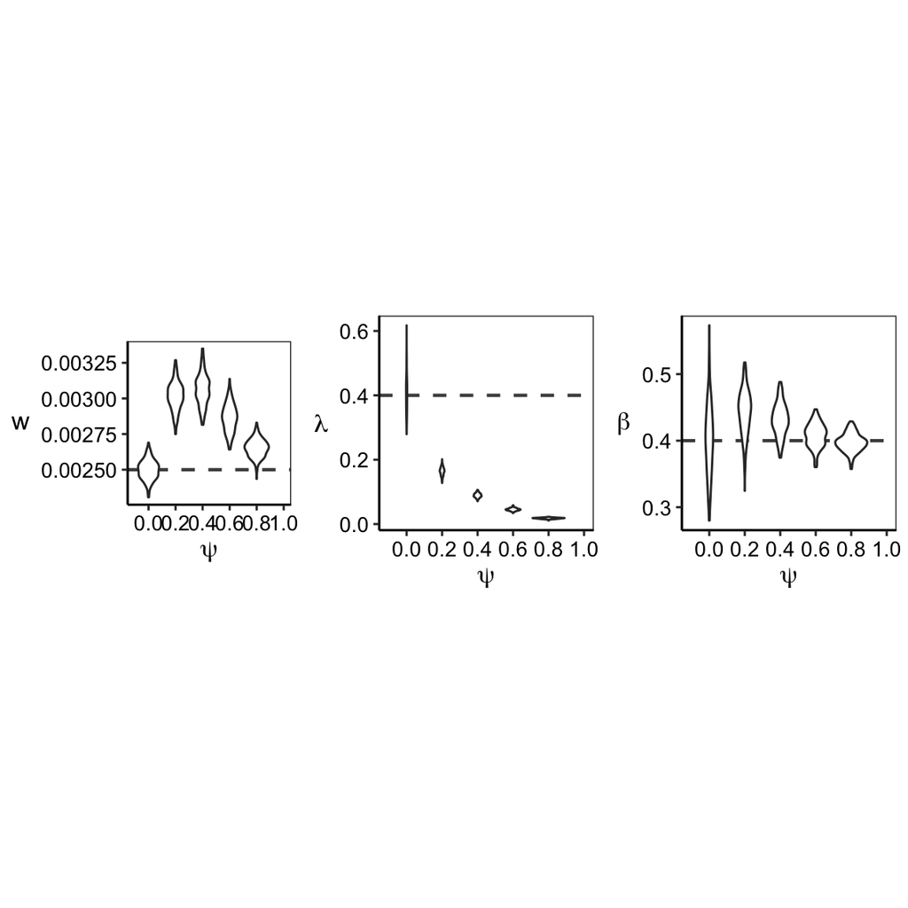

**FIGURE S3: Model misspecification.** Violin plots of maximum likelihood estimates for parameters in a progressive model (i.e., one that assumes $\psi=0$) fit to data generated using a mixture model with selected values of $\psi\ge0$ assuming 50,000 women were screened annually at ages 50–54 with follow-up to age 60 years and the screening test has 40% sensitivity. Results based on n=200 simulations per $\psi$-value.